# AI Foundations: AII 600

## Galton Board: Physical demonstration of CLT

**Galton Board:** (Physical demonstration of CLT)[https://youtu.be/zeJD6dqJ5lo?si=Pm_QVnXr4H403yYu]

- Each pin = binomial draw
- Each row = summand
- Bottom location = sum of binomial draws

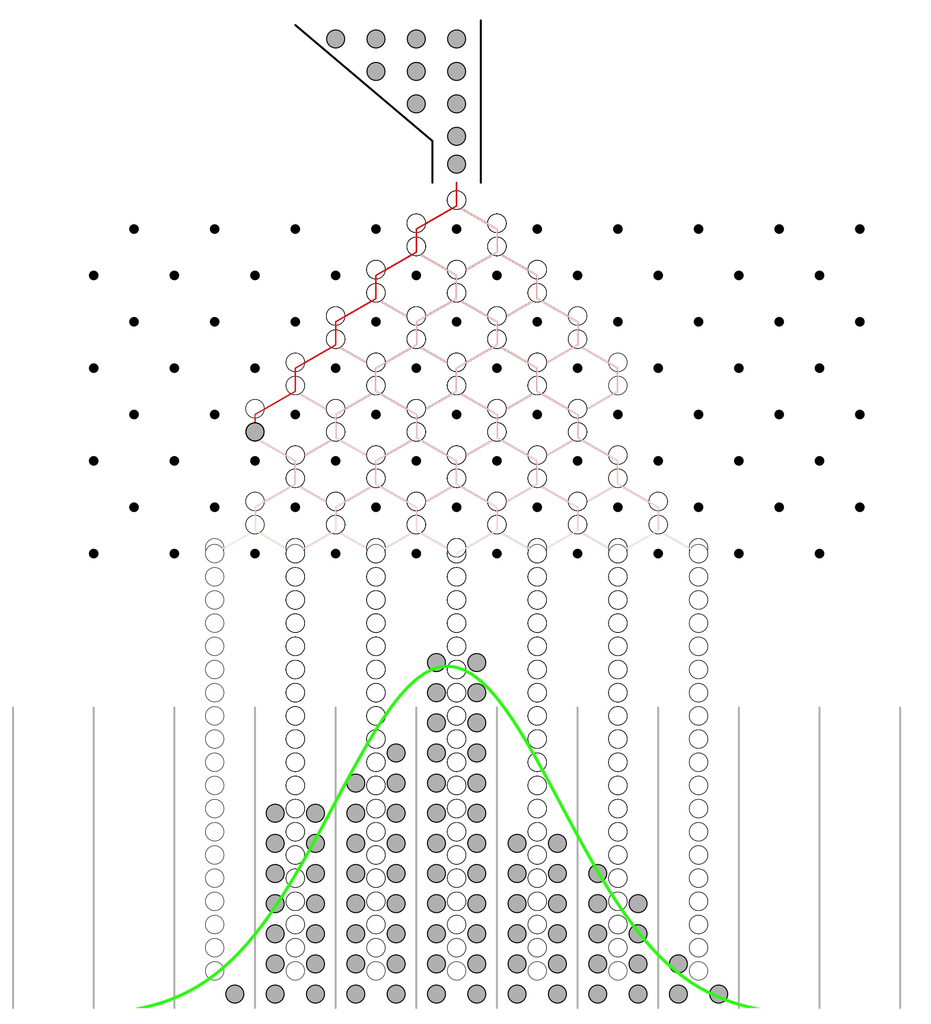

Figure 1: Galton Board

## Android Earthquake Alerts: CLT in Action

**The Challenge:**

- Individual phone accelerometers are “noisy sensors”
- Single phone signal = weak, unreliable
- Many false triggers (drops, trucks, music)

**The Solution:**

- Aggregate signals from millions of phones
- Real earthquakes: synchronized vibrations
- Random noise cancels out through averaging

**The Math:** $s_{\bar x} = s/\sqrt{n}$ where $n$ = number of phones With massive $n$, standard error becomes incredibly small!

## Confidence Interval for μ

```r
# 95% confidence interval for μ
alpha <- 0.05
z_critical <- qnorm(1 - alpha/2)
se_mu <- sigma_mle / sqrt(n)
ci_lower <- mu_mle - z_critical * se_mu
ci_upper <- mu_mle + z_critical * se_mu

cat("95% Confidence Interval for μ:\n")
```

```
95% Confidence Interval for μ:
```

```r
cat("Lower bound:", round(ci_lower, 2))
```

```
Lower bound: 102.44
```

```r
cat("Upper bound:", round(ci_upper, 2))
```

```
Upper bound: 104.21
```

```r
cat("Margin of error:", round(z_critical * se_mu, 2))
```

```
Margin of error: 0.89
```

## Bernoulli Likelihood

For an i.i.d. sample $X_1, \dots, X_n$ from a Bernoulli(p) distribution, the likelihood is:
$$l(p) = \prod_{i=1}^n p^{x_i} (1-p)^{1-x_i}$$

The log-likelihood is:
$$l(p) = \sum_{i=1}^n \ln\left(p^{x_i} (1-p)^{1-x_i}\right)$$
$$= \sum_{i=1}^n \left( x_i \ln(p) + (1-x_i) \ln(1-p) \right)$$

## Bernoulli MLE

To find the maximum, we take the derivative with respect to p and set it to zero:
$$\frac{\partial l}{\partial p} = \frac{1}{p}\sum_{i=1}^n x_i - \frac{1}{1-p}\sum_{i=1}^n (1-x_i) = 0$$
$$\implies \hat{p}_{MLE} = \frac{1}{n}\sum_{i=1}^n x_i = \bar{X}$$

## MLE: Poisson Example

For an i.i.d. sample $X_1, \dots, X_n$ from a Poisson(λ) distribution, the log-likelihood is:
$$l(\lambda) = \sum_{i=1}^n \ln\left(\frac{\lambda^{X_i} e^{-\lambda}}{X_i!}\right) = (\ln \lambda) \sum X_i - n\lambda - \sum \ln(X_i!)$$

To find the maximum, we take the derivative with respect to λ and set it to zero:
$$\frac{dl}{d\lambda} = \frac{1}{\lambda}\sum X_i - n = 0$$
$$\implies \hat{\lambda}_{MLE} = \frac{\sum X_i}{n} = \bar{X}$$

For the Poisson distribution, the Method of Moments and the Maximum Likelihood estimates are the same.

## Gamma Distribution

The mean and variance of the Gamma distribution are:
$$E(X) = \alpha\lambda$$
$$Var(X) = \alpha\lambda^2$$

## Examples of Gamma Distribution

The Gamma distribution is extremely versatile and appears in many real-world applications:

**Examples:**

- **Waiting times:** Time until the k-th event in a Poisson process (e.g., time until the 5th customer arrives)
- **Reliability engineering:** Time to failure of components or systems
- **Insurance:** Claim amounts and time between claims
- **Weather:** Rainfall amounts, wind speeds
- **Finance:** Stock price movements, portfolio losses
- **Medical:** Time to recovery, survival times
- **Queue theory:** Service times in complex systems

## MLE: Gamma Distribution Example

For the Gamma distribution, the log-likelihood is:
$$l(\alpha, \lambda) = n\alpha\ln(\lambda) - n\ln(\Gamma(\alpha)) + (\alpha-1)\sum\ln(X_i) - \lambda\sum X_i$$
The MLEs for α and λ don’t have a simple closed-form solution and must be found numerically by maximizing this function.

Let’s fit a Gamma distribution to the inter-arrival times of gamma-rays.

## MLE: Gamma Distribution Example

```r
#| fig-width: 8
#| fig-height: 5

# Load the data
gamma_arrivals <- read.csv("data/gamma-arrivals.txt", header = FALSE)$V1

# Log-likelihood function for the Gamma distribution
log_likelihood_gamma <- function(params, data) {
  alpha <- params[1]
  lambda <- params[2]
  if (alpha <= 0 || lambda <= 0) return(NA) # Parameters must be positive

  n <- length(data)
  loglik <- n * alpha * log(lambda) - n * lgamma(alpha) +
            (alpha - 1) * sum(log(data)) - lambda * sum(data)
  return(-loglik) # optim minimizes by default, so we return negative log-likelihood
}

# Use Method of Moments for starting values
mean_g <- mean(gamma_arrivals)
var_g <- var(gamma_arrivals)
alpha_start <- mean_g^2 / var_g
lambda_start <- mean_g / var_g

# Find MLEs using numerical optimization
mle_fit <- optim(par = c(alpha_start, lambda_start),
                 fn = log_likelihood_gamma,
                 data = gamma_arrivals)
alpha_mle <- mle_fit$par[1]
lambda_mle <- mle_fit$par[2]

print(paste("MLE for alpha:", round(alpha_mle, 4)))
```

```
[1] "MLE for alpha: 1.0263"
```

```r
print(paste("MLE for lambda:", round(lambda_mle, 4)))
```

```
[1] "MLE for lambda: 0.0128"
```

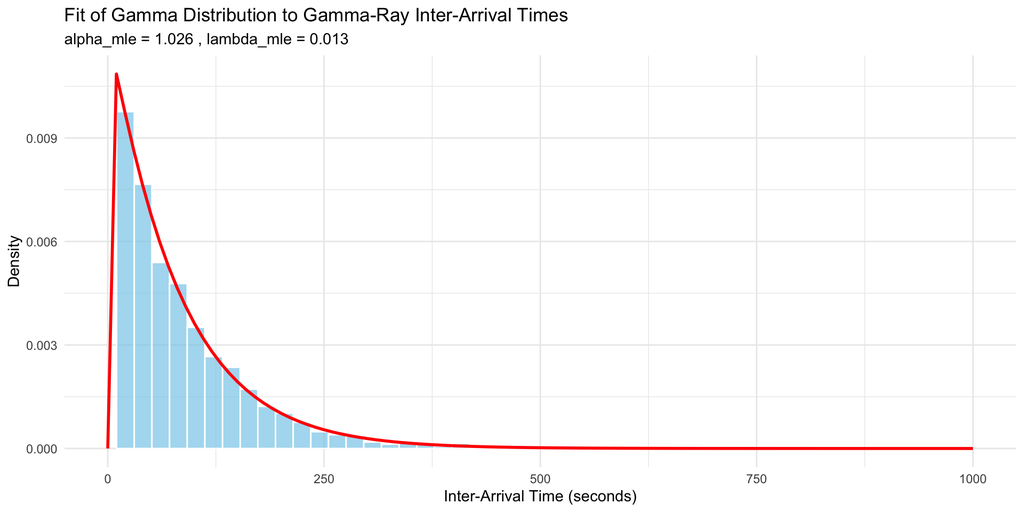

```r
# Plotting
ggplot(data.frame(x = gamma_arrivals), aes(x = x)) +
  geom_histogram(aes(y = after_stat(density)), bins = 50, fill = "skyblue", color = "white", alpha = 0.7) +
  stat_function(fun = dgamma, args = list(shape = alpha_mle, rate = lambda_mle), color = "red", linewidth = 1) +
  labs(title = "Fit of Gamma Distribution to Gamma-Ray Inter-Arrival Times",
       subtitle = paste("alpha_mle =", round(alpha_mle, 3), ", lambda_mle =", round(lambda_mle, 3)),
       x = "Inter-Arrival Time (seconds)",
       y = "Density") +
  xlim(0, 1000) +
  theme_minimal()
```

## Properties of Maximum Likelihood Estimators

Under general “smoothness” conditions, MLEs have desirable large-sample properties:

1. **Consistency:** As the sample size $n \to \infty$, the MLE $\hat{\theta}_n$ converges in probability to the true parameter value $\theta_0$.
2. **Asymptotic Normality:** The distribution of $\sqrt{n}(\hat{\theta}_n - \theta_0)$ approaches a Normal distribution with mean 0.
3. **Asymptotic Efficiency:** For large samples, the MLE achieves the smallest possible variance among a large class of unbiased estimators (the Cramér-Rao lower bound).

This provides a strong theoretical justification for using MLEs.

## Confidence Intervals from MLEs

The asymptotic normality of MLEs allows us to construct approximate confidence intervals. The variance of the limiting normal distribution is given by $1/I(\theta_0)$, where $I(\theta)$ is the **Fisher Information**.

$$I(\theta) = E\left[\left(\frac{\partial}{\partial\theta} \ln f(X|\theta)\right)^2\right] = -E\left[\frac{\partial^2}{\partial\theta^2} \ln f(X|\theta)\right]$$

An approximate $100(1-\alpha)\%$ confidence interval for $\theta$ is:
$$\hat{\theta} \pm z_{\alpha/2} \frac{1}{\sqrt{nI(\hat{\theta})}}$$
The term $\frac{1}{\sqrt{nI(\hat{\theta})}}$ is the estimated standard error of the MLE.

## MLE: Negative Binomial Example

The Negative Binomial distribution is often used for count data that is “overdispersed” (variance is greater than the mean), making it a good alternative to the Poisson. Let’s fit it to data on potato beetle counts.

```r
#| message: false
#| warning: false
#| fig-width: 8
#| fig-height: 5

library(MASS) # For fitdistr

# Load data and expand from frequency table
evans <- read.csv("data/evans1953.txt")
beetle_data <- rep(evans$Count, evans$PotatoBeetles)

# Use fitdistr to find MLEs for the negative binomial distribution
# 'size' is r (number of successes), 'mu' is the mean
neg_bin_fit <- fitdistr(beetle_data, "negative binomial")
r_hat <- neg_bin_fit$estimate["size"]
mu_hat <- neg_bin_fit$estimate["mu"]

print(paste("MLE for r (size):", round(r_hat, 2)))
```

```
[1] "MLE for r (size): 2.24"
```

```r
print(paste("MLE for mean (mu):", round(mu_hat, 2)))
```

```
[1] "MLE for mean (mu): 4.7"
```

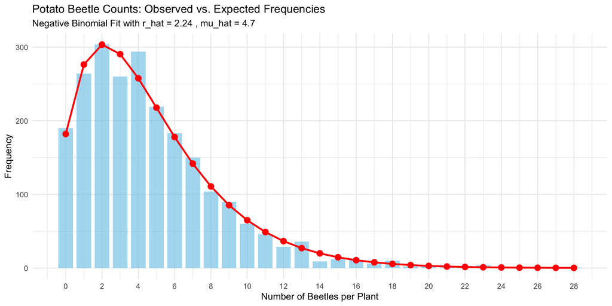

```r
# Calculate expected frequencies
max_count <- max(evans$Count)
counts_range <- 0:max_count
expected_freq <- length(beetle_data) * dnbinom(counts_range, size = r_hat, mu = mu_hat)

# Create a data frame for plotting
plot_data <- data.frame(
  Count = counts_range,
  Observed = sapply(counts_range, function(c) sum(beetle_data == c)),
  Expected = expected_freq
)

# Plotting observed vs. expected
ggplot(plot_data, aes(x = Count)) +
  geom_bar(aes(y = Observed), stat = "identity", fill = "skyblue", alpha = 0.7, width = 0.8) +
  geom_line(aes(y = Expected), color = "red", size = 1) +
  geom_point(aes(y = Expected), color = "red", size = 3) +
  scale_x_continuous(breaks = seq(0, max_count, by = 2)) +
  labs(title = "Potato Beetle Counts: Observed vs. Expected Frequencies",
       subtitle = paste("Negative Binomial Fit with r_hat =", round(r_hat, 2), ", mu_hat =", round(mu_hat, 2)),
       x = "Number of Beetles per Plant",
       y = "Frequency") +
  theme_minimal()
```

## MLE For LLM

Large Language Models (LLMs) like GPT, BERT, and others are trained using Maximum Likelihood Estimation as a core principle.

**The Setup:** - Given a sequence of tokens $w_1, w_2, \ldots, w_n$ (words, subwords, or characters) - Model parameterized by $\theta$ (neural network weights) - Goal: Find $\theta$ that maximizes the likelihood of observing the training text

**The Likelihood:** For autoregressive models (like GPT), we factorize the joint probability:
$$P(w_1, w_2, \ldots, w_n | \theta) = \prod_{i=1}^n P(w_i | w_1, \ldots, w_{i-1}, \theta)$$

The MLE objective is to maximize this likelihood over the training corpus.

## MLE Training Process for LLMs

**Log-Likelihood Objective:**
$$\mathcal{L}(\theta) = \sum_{i=1}^n \log P(w_i | w_1, \ldots, w_{i-1}, \theta)$$

**Cross-Entropy Loss:** In practice, this becomes minimizing the cross-entropy loss:
$$\text{Loss} = -\frac{1}{n} \sum_{i=1}^n \log P(w_i | \text{context}, \theta)$$

**Key Components:**

- **Neural Network:** Transformer architecture with parameters $\theta$
- **Softmax Output:** $P(w_i | \text{context}, \theta) = \frac{\exp(z_i)}{\sum_j \exp(z_j)}$ where $z_i$ are logits
- **Gradient Descent:** Optimize $\theta$ using backpropagation and variants like Adam

**Training Data:** Massive text corpora (books, web pages, articles) containing billions of tokens

## MLE Challenges and Considerations in LLMs

**Computational Challenges:**

- **Scale:** Billions/trillions of parameters require distributed training
- **Memory:** Large vocabularies (50K-100K+ tokens) make softmax expensive
- **Approximations:** Techniques like hierarchical softmax, noise contrastive estimation

**Statistical Considerations:**

- **Overfitting:** Regularization through dropout, weight decay
- **Data Quality:** MLE assumes training data represents true distribution
- **Exposure Bias:** Training uses teacher forcing, but inference is autoregressive

**Modern Adaptations:**

- **Masked Language Modeling:** BERT uses bidirectional context (not strictly autoregressive)
- **Reinforcement Learning:** RLHF (Reinforcement Learning from Human Feedback) goes beyond pure MLE
- **Temperature Scaling:** Adjust sharpness of probability distributions during generation

The success of LLMs demonstrates MLE’s power when combined with sufficient data and computational resources.

## Conclusion

- Data quality: no data, good data, bad data; case 3 looks like 2.
- Unsupervised: correlation, then Dirichlet draws on a simplex. No designated $y$.
- Then a named law: method of moments, maximum likelihood.

Supervised learning is the next notes: $y = f(x)$.